# Introduction to Computer Vision: Plant Seedlings Classification

## Problem Statement

### Context

In recent times, the field of agriculture has been in urgent need of modernizing, since the amount of manual work people need to put in to check if plants are growing correctly is still highly extensive. Despite several advances in agricultural technology, people working in the agricultural industry still need to have the ability to sort and recognize different plants and weeds, which takes a lot of time and effort in the long term. The potential is ripe for this trillion-dollar industry to be greatly impacted by technological innovations that cut down on the requirement for manual labor, and this is where Artificial Intelligence can actually benefit the workers in this field, as **the time and energy required to identify plant seedlings will be greatly shortened by the use of AI and Deep Learning.** The ability to do so far more efficiently and even more effectively than experienced manual labor, could lead to better crop yields, the freeing up of human inolvement for higher-order agricultural decision making, and in the long term will result in more sustainable environmental practices in agriculture as well.

### Objective

The aim of this project is to Build a Convolutional Neural Netowrk to classify plant seedlings into their respective categories.

### Data Dictionary

The Aarhus University Signal Processing group, in collaboration with the University of Southern Denmark, has recently released a dataset containing **images of unique plants belonging to 12 different species.**

- The dataset can be download from Olympus.
- The data file names are:
  - images.npy
  - Labels.csv
- Due to the large volume of data, the images were converted to the images.npy file and the labels are also put into Labels.csv, so that you can work on the data/project seamlessly without having to worry about the high data volume.
- The goal of the project is to create a classifier capable of determining a plant's species from an image.

**List of Species**

- Black-grass
- Charlock
- Cleavers
- Common Chickweed
- Common Wheat
- Fat Hen
- Loose Silky-bent
- Maize
- Scentless Mayweed
- Shepherds Purse
- Small-flowered Cranesbill
- Sugar beet

### **Note: Please use GPU runtime on Google Colab to execute the code faster.**

## Importing necessary libraries

```python
# Installing the libraries with the specified version.
# uncomment and run the following line if Google Colab is being used
!pip install tensorflow==2.18.0 scikit-learn==1.3.2 seaborn==0.13.1 matplotlib==3.8.0 numpy==1.26 pandas==2.2.2 opencv-python==4.8.0.76 -q --user --no-warn-script-location
```

```python
# Installing the libraries with the specified version.
# uncomment and run the following lines if Jupyter Notebook is being used
#!pip install tensorflow==2.13.0 scikit-learn==1.2.2 seaborn==0.11.1 matplotlib==3.3.4 numpy==1.24.3 pandas==1.5.2 opencv-python==4.8.0.76 -q --user
```

**Note**: *After running the above cell, kindly restart the notebook kernel and run all cells sequentially from the start again.*

```python
import os
import numpy as np                                                                               # Importing numpy for Matrix Operations
import pandas as pd                                                                              # Importing pandas to read CSV files
import matplotlib.pyplot as plt                                                                  # Importting matplotlib for Plotting and visualizing images
import math                                                                                      # Importing math module to perform mathematical operations
import cv2                                                                                       # Importing openCV for image processing
import seaborn as sns                                                                            # Importing seaborn to plot graphs


# Tensorflow modules
import tensorflow as tf
from tensorflow.keras.preprocessing.image import ImageDataGenerator                              # Importing the ImageDataGenerator for data augmentation
from tensorflow.keras.models import Sequential                                                   # Importing the sequential module to define a sequential model
from tensorflow.keras.layers import Dense,Dropout,Flatten,Conv2D,MaxPooling2D,BatchNormalization # Defining all the layers to build our CNN Model
from tensorflow.keras.optimizers import Adam,SGD                                                 # Importing the optimizers which can be used in our model
from tensorflow.keras.callbacks import ReduceLROnPlateau                                         # Import ReduceLROnPlateau
from sklearn import preprocessing                                                                # Importing the preprocessing module to preprocess the data
from sklearn.model_selection import train_test_split                                             # Importing train_test_split function to split the data into train and test
from sklearn.metrics import confusion_matrix,accuracy_score,recall_score,precision_score,f1_score# Importing the required metrics for model evaluation

# Display images using OpenCV
from google.colab.patches import cv2_imshow                                                      # Importing cv2_imshow from google.patches to display images

# Ignore warnings
import warnings
warnings.filterwarnings('ignore')
```

## Loading the dataset

```python
# Uncomment and run the below code if you are using google colab
from google.colab import drive
drive.mount('/content/drive')
```

```python
# Load the image file of the dataset
images = np.load('/content/drive/MyDrive/Data/Plants_Seedling_Classification/images.npy')

# Load the labels file of the dataset
labels = pd.read_csv('/content/drive/MyDrive/Data/Plants_Seedling_Classification/Labels.csv')
```

## Data Overview

### Understand the shape of the dataset

```python
print(images.shape)
print(labels.shape)
```

```
(4750, 128, 128, 3)
(4750, 1)
```

There are 4750 RGB images of shape 128 x 128 X 3, each image having 3 channels.

## Exploratory Data Analysis

- EDA is an important part of any project involving data.
- It is important to investigate and understand the data better before building a model with it.

```python
def plot_images(images,labels):
  num_classes=10                                                                  # Number of Classes
  categories=np.unique(labels)
  keys=dict(labels['Label'])                                                      # Obtaing the unique classes from y_train
  rows = 3                                                                        # Defining number of rows=3
  cols = 4                                                                        # Defining number of columns=4
  fig = plt.figure(figsize=(10, 8))                                               # Defining the figure size to 10x8
  for i in range(cols):
      for j in range(rows):
          random_index = np.random.randint(0, len(labels))                        # Generating random indices from the data and plotting the images
          ax = fig.add_subplot(rows, cols, i * rows + j + 1)                      # Adding subplots with 3 rows and 4 columns
          ax.imshow(images[random_index, :])                                      # Plotting the image
          ax.set_title(keys[random_index])
  plt.show()
```

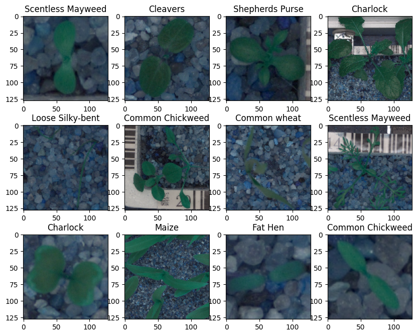

```python
plot_images(images,labels)
```

**Checking for data imbalance**

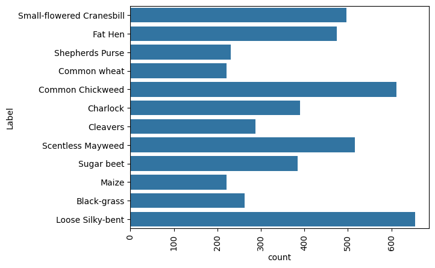

```python
 sns.countplot(labels['Label'])
 plt.xticks(rotation='vertical');
```

- As you can see from the above plot, the dataset is significantly imbalanced.
- The counts range from approximately 200 (for "Common wheat" and "Maize") to over 600 (for "Loose Silky-bent" and "Common Chickweed").

**Questions**

1. How are these different category plant images different from each other?
- The plant images differ based on three key aspects: Leaf Shape, Color & Texture, and Size & Growth Pattern.
2. Is the dataset provided an imbalance? (Check with using bar plots)
- Yes, the dataset provided is significantly imbalanced, with the counts ranging from approximately 200 (for "Common wheat" and "Maize") to over 600 (for "Loose Silky-bent" and "Common Chickweed").

## Data Pre-Processing

### Convert the BGR images to RGB images.

**Plotting images using OpenCV and matplotlib**

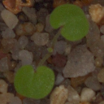

```python
cv2_imshow(images[5])
```

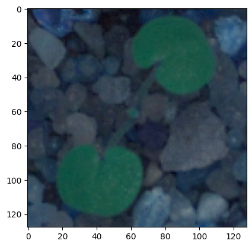

```python
# Plotting an image before converting the images from BGR to RGB
plt.imshow(images[5]);
```

- We can observe that the images are being shown in different colors when plotted with openCV and matplotlib as OpenCV reads images in BGR format and this shows that the given numpy arrays were generated from the original images using OpenCV.
- Now we will convert these BGR images to RGB images so we could interpret them easily.

```python
# Keep a copy of BGR images to compare
imageBGR = images.copy()
# Converting the images from BGR to RGB using cvtColor function of OpenCV
for i in range(len(images)):
  images[i] = cv2.cvtColor(images[i], cv2.COLOR_BGR2RGB)
```

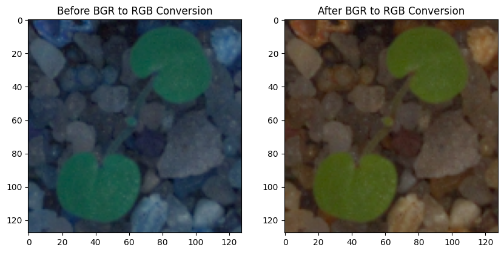

```python
# Plotting an image before and after converting the images from BGR to RGB
fig = plt.figure(figsize=(10, 8))
ax = fig.add_subplot(1, 2,1)
ax.imshow(imageBGR[5])
ax.set_title("Before BGR to RGB Conversion")
ax = fig.add_subplot(1, 2,2)
ax.imshow(images[5])
ax.set_title("After BGR to RGB Conversion");
```

### Resize the images

As the size of the images is large, it may be computationally expensive to train on these larger images; therefore, it is preferable to reduce the image size from 128 to 64.

```python
images_decreased=[]
height = 64
width = 64
dimensions = (width, height)
for i in range(len(images)):
  images_decreased.append( cv2.resize(images[i], dimensions, interpolation=cv2.INTER_LINEAR))
```

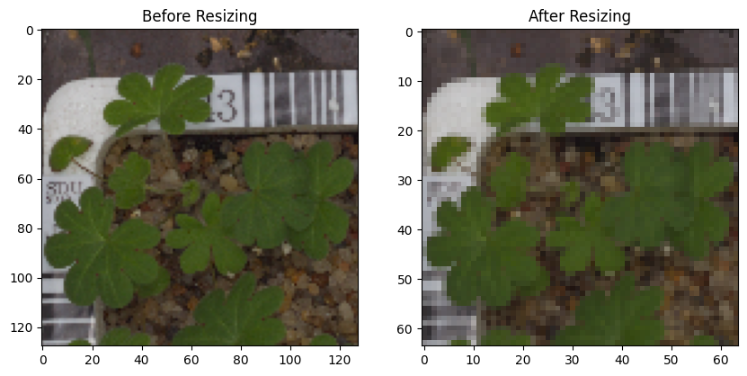

```python
fig = plt.figure(figsize=(10, 8))
ax = fig.add_subplot(1, 2,1)
ax.imshow(images[3])
ax.set_title("Before Resizing")
ax = fig.add_subplot(1, 2,2)
ax.imshow(images_decreased[3])
ax.set_title("After Resizing");
```

### Data Preparation for Modeling

- Before you proceed to build a model, you need to split the data into train, test, and validation to be able to evaluate the model that you build on the train data
- You'll have to encode categorical features and scale the pixel values.
- You will build a model using the train data and then check its performance

**Split the dataset**

- As we have less images in our dataset, we will only use 10% of our data for testing, 10% of our data for validation and 80% of our data for training.
- We are using the train_test_split() function from scikit-learn. Here, we split the dataset into three parts, train,test and validation.

```python
from sklearn.model_selection import train_test_split
X_temp, X_test, y_temp, y_test = train_test_split(np.array(images_decreased),labels , test_size=0.1, random_state=42,stratify=labels)
X_train, X_val, y_train, y_val = train_test_split(X_temp,y_temp , test_size=0.1, random_state=42,stratify=y_temp)
```

```python
print(X_train.shape,y_train.shape)
print(X_val.shape,y_val.shape)
print(X_test.shape,y_test.shape)
```

```
(3847, 64, 64, 3) (3847, 1)
(428, 64, 64, 3) (428, 1)
(475, 64, 64, 3) (475, 1)
```

### Encode the target labels

- Convert labels from names to one hot vectors
- Normalizing the values

```python
# Convert labels from names to one hot vectors.
# Labelbinarizer works similar to onehotencoder

from sklearn.preprocessing import LabelBinarizer
enc = LabelBinarizer()
y_train_encoded = enc.fit_transform(y_train)
y_val_encoded=enc.transform(y_val)
y_test_encoded=enc.transform(y_test)
```

### Data Normalization

Since the **image pixel values range from 0-255**, our method of normalization here will be **scaling** - we shall **divide all the pixel values by 255 to standardize the images to have values between 0-1.**

```python
# Normalizing the image pixels
X_train_normalized = X_train.astype('float32')/255.0
X_val_normalized = X_val.astype('float32')/255.0
X_test_normalized = X_test.astype('float32')/255.0
```

## Model Building

**Let's define a function to output different metrics (including recall) on the train, validation and test set.**

```python
# defining a function to compute different metrics to check performance of CNN model
def model_performance(model, predictors, target,modeldesc=None):
    """
    Function to compute different metrics to check CNN model performance

    model: CNN
    predictors: independent variables
    target: dependent variable
    """

    # predicting using the independent variables
    pred_probs = model.predict(predictors) # Get predicted probabilities
    pred = np.argmax(pred_probs, axis=1)  # Get predicted classes (0-11)

    # Convert target to multiclass format if it's in multilabel-indicator format
    if target.ndim == 2 and target.shape[1] > 1:  # Check if multilabel-indicator
        target = np.argmax(target, axis=1)  # Convert to multiclass format

    acc = accuracy_score(target, pred)  # to compute Accuracy
    recall = recall_score(target, pred, average='weighted')  # to compute weighted Recall
    precision = precision_score(target, pred, average='weighted')  # to compute weighted Precision
    f1 = f1_score(target, pred, average='weighted')  # to compute weighted F1-score

    # creating a dataframe of metrics along with model description
    df_perf = pd.DataFrame(
        {
            "Model": modeldesc,
            "Accuracy": acc,
            "Recall": recall,
            "Precision": precision,
            "F1": f1,
        },
        index=[0],
    )

    return df_perf
```

```python
columns = ["Model","Accuracy","Recall","Precision","F1"]

training_results = pd.DataFrame(columns=columns)
validation_results = pd.DataFrame(columns=columns)
test_results = pd.DataFrame(columns=columns)
```

Let's create a CNN model sequentially, where we will be adding the layers one after another.

First, we need to clear the previous model's history from the session even if a single model can run multiple times on the same data.

In Keras, we need a special command to clear the model's history, otherwise the previous model history remains in the backend.

Also, let's fix the seed again after clearing the backend.

Let's **set the seed for random number generators in Numpy, the Random library in Python, and in TensorFlow** to be able to reproduce the same results every time we run the code.

```python
# Clearing backend
from tensorflow.keras import backend
backend.clear_session()
```

```python
# Fixing the seed for random number generators
import random
np.random.seed(42)
random.seed(42)
tf.random.set_seed(42)
```

Now, let's build a **CNN Model** with the following 2 main parts -

1. **The Feature Extraction layers** which are comprised of convolutional and pooling layers.
2. **The Fully Connected classification layers** for prediction.

```python
# Intializing a sequential model
model = Sequential()

# Adding first conv layer with 64 filters and kernel size 3x3 , padding 'same' provides the output size same as the input size
# Input_shape denotes input image dimension of images
model.add(Conv2D(64, (3, 3), activation='relu', padding="same", input_shape=(64, 64, 3)))

# Adding max pooling to reduce the size of output of first conv layer
model.add(MaxPooling2D((2, 2), padding = 'same'))

model.add(Conv2D(32, (3, 3), activation='relu', padding="same"))
model.add(MaxPooling2D((2, 2), padding = 'same'))

# flattening the output of the conv layer after max pooling to make it ready for creating dense connections
model.add(Flatten())

# Adding a fully connected dense layer with 100 neurons
model.add(Dense(16, activation='relu'))
model.add(Dropout(0.3))
# Adding the output layer with 12 neurons and activation functions as softmax since this is a multi-class classification problem
model.add(Dense(12, activation='softmax'))

# Using SGD Optimizer
# opt = SGD(learning_rate=0.01, momentum=0.9)
opt=Adam()
# Compile model
model.compile(optimizer=opt, loss='categorical_crossentropy', metrics=['accuracy'])

# Generating the summary of the model
model.summary()
```

```
Model: "sequential"
```

```
┏━━━━━━━━━━━━━━━━━━━━━━━━━━━━━━━━━━━━━━┳━━━━━━━━━━━━━━━━━━━━━━━━━━━━━┳━━━━━━━━━━━━━━━━━┓
┃ Layer (type)                         ┃ Output Shape                ┃         Param # ┃
┡━━━━━━━━━━━━━━━━━━━━━━━━━━━━━━━━━━━━━━╇━━━━━━━━━━━━━━━━━━━━━━━━━━━━━╇━━━━━━━━━━━━━━━━━┩
│ conv2d (Conv2D)                      │ (None, 64, 64, 64)          │           1,792 │
├──────────────────────────────────────┼─────────────────────────────┼─────────────────┤
│ max_pooling2d (MaxPooling2D)         │ (None, 32, 32, 64)          │               0 │
├──────────────────────────────────────┼─────────────────────────────┼─────────────────┤
│ conv2d_1 (Conv2D)                    │ (None, 32, 32, 32)          │          18,464 │
├──────────────────────────────────────┼─────────────────────────────┼─────────────────┤
│ max_pooling2d_1 (MaxPooling2D)       │ (None, 16, 16, 32)          │               0 │
├──────────────────────────────────────┼─────────────────────────────┼─────────────────┤
│ flatten (Flatten)                    │ (None, 8192)                │               0 │
├──────────────────────────────────────┼─────────────────────────────┼─────────────────┤
│ dense (Dense)                        │ (None, 16)                  │         131,088 │
├──────────────────────────────────────┼─────────────────────────────┼─────────────────┤
│ dropout (Dropout)                    │ (None, 16)                  │               0 │
├──────────────────────────────────────┼─────────────────────────────┼─────────────────┤
│ dense_1 (Dense)                      │ (None, 12)                  │             204 │
└──────────────────────────────────────┴─────────────────────────────┴─────────────────┘
```

```
 Total params: 151,548 (591.98 KB)
```

```
 Trainable params: 151,548 (591.98 KB)
```

```
 Non-trainable params: 0 (0.00 B)
```

### **Fitting the model on the train data**

```python
history_1 = model.fit(
            X_train_normalized, y_train_encoded,
            epochs=30,
            validation_data=(X_val_normalized,y_val_encoded),
            batch_size=32,
            verbose=2
)
```

```
121/121 - 18s - 147ms/step - accuracy: 0.1014 - loss: 2.4630 - val_accuracy: 0.1028 - val_loss: 2.4366
121/121 - 8s - 65ms/step - accuracy: 0.2033 - loss: 2.3312 - val_accuracy: 0.3458 - val_loss: 2.1424
121/121 - 1s - 6ms/step - accuracy: 0.2956 - loss: 2.0227 - val_accuracy: 0.4252 - val_loss: 1.7467
121/121 - 1s - 6ms/step - accuracy: 0.3338 - loss: 1.8541 - val_accuracy: 0.4836 - val_loss: 1.5811
121/121 - 1s - 12ms/step - accuracy: 0.3603 - loss: 1.7817 - val_accuracy: 0.4860 - val_loss: 1.5508
121/121 - 1s - 8ms/step - accuracy: 0.3670 - loss: 1.7212 - val_accuracy: 0.5327 - val_loss: 1.4513
121/121 - 1s - 9ms/step - accuracy: 0.3803 - loss: 1.6999 - val_accuracy: 0.5514 - val_loss: 1.4015
121/121 - 1s - 10ms/step - accuracy: 0.3928 - loss: 1.6526 - val_accuracy: 0.5374 - val_loss: 1.3453
121/121 - 1s - 10ms/step - accuracy: 0.3995 - loss: 1.6311 - val_accuracy: 0.5514 - val_loss: 1.3307
121/121 - 1s - 10ms/step - accuracy: 0.4008 - loss: 1.6022 - val_accuracy: 0.5350 - val_loss: 1.3349
121/121 - 1s - 7ms/step - accuracy: 0.4006 - loss: 1.5793 - val_accuracy: 0.5421 - val_loss: 1.2825
121/121 - 1s - 10ms/step - accuracy: 0.4042 - loss: 1.5611 - val_accuracy: 0.5374 - val_loss: 1.2995
121/121 - 1s - 10ms/step - accuracy: 0.4185 - loss: 1.5597 - val_accuracy: 0.5164 - val_loss: 1.3415
121/121 - 1s - 10ms/step - accuracy: 0.4206 - loss: 1.5328 - val_accuracy: 0.5327 - val_loss: 1.3041
121/121 - 1s - 11ms/step - accuracy: 0.4289 - loss: 1.5156 - val_accuracy: 0.5701 - val_loss: 1.2495
121/121 - 1s - 7ms/step - accuracy: 0.4268 - loss: 1.5205 - val_accuracy: 0.5631 - val_loss: 1.2500
121/121 - 1s - 11ms/step - accuracy: 0.4346 - loss: 1.5048 - val_accuracy: 0.5607 - val_loss: 1.2414
121/121 - 1s - 10ms/step - accuracy: 0.4268 - loss: 1.4849 - val_accuracy: 0.5491 - val_loss: 1.2552
121/121 - 1s - 10ms/step - accuracy: 0.4344 - loss: 1.4927 - val_accuracy: 0.5397 - val_loss: 1.2742
121/121 - 1s - 6ms/step - accuracy: 0.4377 - loss: 1.4876 - val_accuracy: 0.5421 - val_loss: 1.2614
121/121 - 1s - 6ms/step - accuracy: 0.4349 - loss: 1.4700 - val_accuracy: 0.5631 - val_loss: 1.2268
121/121 - 1s - 10ms/step - accuracy: 0.4476 - loss: 1.4396 - val_accuracy: 0.5748 - val_loss: 1.2058
121/121 - 1s - 10ms/step - accuracy: 0.4515 - loss: 1.4321 - val_accuracy: 0.5771 - val_loss: 1.2014
121/121 - 1s - 6ms/step - accuracy: 0.4471 - loss: 1.4281 - val_accuracy: 0.5631 - val_loss: 1.2121
121/121 - 1s - 6ms/step - accuracy: 0.4468 - loss: 1.4367 - val_accuracy: 0.5771 - val_loss: 1.1893
121/121 - 1s - 10ms/step - accuracy: 0.4562 - loss: 1.3979 - val_accuracy: 0.5701 - val_loss: 1.2073
121/121 - 1s - 10ms/step - accuracy: 0.4656 - loss: 1.3762 - val_accuracy: 0.5607 - val_loss: 1.2140
121/121 - 1s - 12ms/step - accuracy: 0.4643 - loss: 1.3865 - val_accuracy: 0.5537 - val_loss: 1.2626
121/121 - 1s - 10ms/step - accuracy: 0.4760 - loss: 1.3871 - val_accuracy: 0.5888 - val_loss: 1.1775
121/121 - 1s - 6ms/step - accuracy: 0.4801 - loss: 1.3690 - val_accuracy: 0.5748 - val_loss: 1.1916
```

### **Model Evaluation**

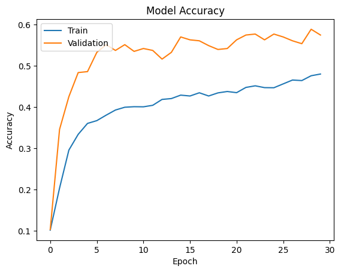

```python
plt.plot(history_1.history['accuracy'])
plt.plot(history_1.history['val_accuracy'])
plt.title('Model Accuracy')
plt.ylabel('Accuracy')
plt.xlabel('Epoch')
plt.legend(['Train', 'Validation'], loc='upper left')
plt.show()
```

```python
modeldesc="CNN"
training_df = model_performance(model, X_train_normalized, y_train_encoded,modeldesc)
validation_df = model_performance(model, X_val_normalized, y_val_encoded,modeldesc)


training_results = pd.concat([training_results,training_df], ignore_index=True)
validation_results = pd.concat([validation_results, validation_df], ignore_index=True)
```

```
121/121 ━━━━━━━━━━━━━━━━━━━━ 1s 5ms/step
14/14 ━━━━━━━━━━━━━━━━━━━━ 0s 18ms/step
```

```python
training_results[training_results['Model']==modeldesc]
```

|  | Model | Accuracy | Recall | Precision | F1 |
| --- | --- | --- | --- | --- | --- |
| 0 | CNN | 0.655056 | 0.655056 | 0.602149 | 0.577568 |

```python
validation_results[validation_results['Model']==modeldesc]
```

|  | Model | Accuracy | Recall | Precision | F1 |
| --- | --- | --- | --- | --- | --- |
| 0 | CNN | 0.574766 | 0.574766 | 0.492668 | 0.497251 |

**Observations:**

- **Validation Accuracy Above Training:** We can observe from the plot that the validation accuracy curve is consistently above the training accuracy curve throughout the training process.
- **General Trend of Increasing Accuracy:** Both curves show a general trend of increasing accuracy.
- **Final Validation Accuracy:** The model achieves a final validation accuracy of 0.5748 at the last epoch, while the corresponding training accuracy is 0.4801.
- **Overfitting Indication:** The training accuracy (0.655056) being higher than the validation accuracy (0.574766) suggests some degree of overfitting.
- **Low Overall Performance:** The model's overall performance is relatively low, suggesting that it may not be effectively capturing the underlying patterns in the data.

### **Evaluating the model on test data**

```python
accuracy = model.evaluate(X_test_normalized, y_test_encoded, verbose=2)
```

```
15/15 - 1s - 44ms/step - accuracy: 0.5600 - loss: 1.2530
```

```python
test_df = model_performance(model, X_test_normalized, y_test_encoded,modeldesc)
test_results = pd.concat([test_results,test_df], ignore_index=True)
```

```
15/15 ━━━━━━━━━━━━━━━━━━━━ 0s 17ms/step
```

```python
test_results[test_results['Model']==modeldesc]
```

|  | Model | Accuracy | Recall | Precision | F1 |
| --- | --- | --- | --- | --- | --- |
| 0 | CNN | 0.56 | 0.56 | 0.463832 | 0.482869 |

### **Generating the predictions using test data**

```python
# Here we would get the output as probablities for each category
y_pred=model.predict(X_test_normalized)
```

```
15/15 ━━━━━━━━━━━━━━━━━━━━ 0s 4ms/step
```

```python
y_pred
```

```
array([[7.44014460e-06, 1.95613266e-05, 5.40612382e-06, ...,
        5.42345047e-02, 1.28821212e-05, 9.25465208e-03],
       [3.21619641e-11, 5.73280863e-02, 1.17131267e-02, ...,
        1.09898940e-01, 7.78479815e-01, 1.73142031e-02],
       [1.00876252e-06, 6.17412291e-02, 3.10301334e-02, ...,
        1.06465422e-01, 5.56862235e-01, 6.47441298e-02],
       ...,
       [2.51659840e-01, 1.30904532e-09, 1.18031085e-05, ...,
        3.71413300e-08, 2.47222487e-09, 3.27231123e-06],
       [1.46968732e-05, 8.94085897e-05, 1.29209075e-03, ...,
        3.34321409e-02, 2.78780099e-05, 4.31319885e-02],
       [1.06739055e-04, 1.20982550e-01, 9.02311206e-02, ...,
        1.20472081e-01, 3.55413169e-01, 9.50125158e-02]], dtype=float32)
```

### **Plotting the Confusion Matrix**

- The Confusion matrix is also defined as an inbuilt function in the TensorFlow module, so we can use that for evaluating the classification model.
- The Confusion matrix expects categorical data as input. However, y_test_encoded is an encoded value, whereas y_pred has probabilities. So,we must retrieve the categorical values from the encoded values.
- We will use the `argmax()` function to obtain the maximum value over each category on both y_test_encoded and y_pred and obtain their respective classes.

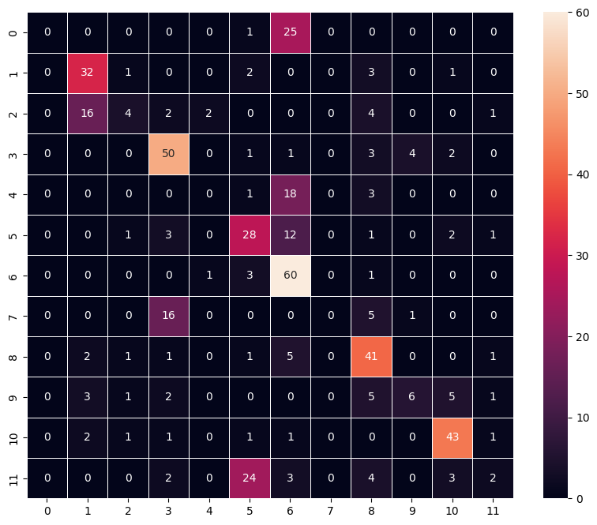

```python
# Obtaining the categorical values from y_test_encoded and y_pred
y_pred_arg=np.argmax(y_pred,axis=1)
y_test_arg=np.argmax(y_test_encoded,axis=1)

# Plotting the Confusion Matrix using confusion matrix() function which is also predefined tensorflow module
confusion_matrix = tf.math.confusion_matrix(y_test_arg,y_pred_arg)
f, ax = plt.subplots(figsize=(10, 8))
sns.heatmap(
    confusion_matrix,
    annot=True,
    linewidths=.4,
    fmt="d",
    square=True,
    ax=ax
)
plt.show()
```

**Observations**

- **Overall Misclassification:** We observe significant misclassification across several classes.
- **Well-Classified Classes:** Classes 1, 3, 6, 8, and 10 are relatively well classified.
- **Complete Misclassification:** Classes 0, 4, and 7 are completely misclassified.
- **Frequent Misclassification:** Classes 2, 9, and 11 are frequently misclassified, indicating difficulty in distinguishing them.
- **Partial Classification Success:** Class 5 shows partial success in learning the features, exhibiting moderate classification.

## Model Performance Improvement

**Reducing the Learning Rate:**

**Hint**: Use **ReduceLRonPlateau()** function that will be used to decrease the learning rate by some factor, if the loss is not decreasing for some time. This may start decreasing the loss at a smaller learning rate. There is a possibility that the loss may still not decrease. This may lead to executing the learning rate reduction again in an attempt to achieve a lower loss.

```python
# Create a ReduceLROnPlateau callback
reduce_lr = ReduceLROnPlateau(
    monitor='val_accuracy',   # Metric to monitor
    factor=0.2,               # Reduce the learning rate by 80%
    patience=3,               # Number of epochs with no improvement after which learning rate will be reduced
    min_lr=1e-5,              # Minimum learning rate
    verbose=1
)
```

### **Data Augmentation**

Remember, **data augmentation should not be used in the validation/test data set**.

```python
# Clearing backend
from tensorflow.keras import backend
backend.clear_session()

# Fixing the seed for random number generators
import random
np.random.seed(42)
random.seed(42)
tf.random.set_seed(42)
```

```python
# All images to be rescaled by 1/255.
train_datagen = ImageDataGenerator(
                              #rescale=1/255.0,  # Include rescale parameter for normalization
                              rotation_range=20,
                              zoom_range=0.2,
                              fill_mode='nearest'
                              )
```

```python
# Intializing a sequential model
model_da = Sequential()

# Adding first conv layer with 64 filters and kernel size 3x3 , padding 'same' provides the output size same as the input size
# Input_shape denotes input image dimension images
model_da.add(Conv2D(64, (3, 3), activation='relu', padding="same", input_shape=(64, 64, 3)))

# Adding max pooling to reduce the size of output of first conv layer
model_da.add(MaxPooling2D((2, 2), padding = 'same'))
# model.add(BatchNormalization())
model_da.add(Conv2D(32, (3, 3), activation='relu', padding="same"))
model_da.add(MaxPooling2D((2, 2), padding = 'same'))
model_da.add(BatchNormalization())
# flattening the output of the conv layer after max pooling to make it ready for creating dense connections
model_da.add(Flatten())

# Adding a fully connected dense layer with 100 neurons
model_da.add(Dense(16, activation='relu'))
model_da.add(Dropout(0.3))
# Adding the output layer with 12 neurons and activation functions as softmax since this is a multi-class classification problem
model_da.add(Dense(12, activation='softmax'))

# Using SGD Optimizer
# opt = SGD(learning_rate=0.01, momentum=0.9)
opt=Adam()
# Compile model
model_da.compile(optimizer=opt, loss='categorical_crossentropy', metrics=['accuracy'])

# Generating the summary of the model
model_da.summary()
```

```
Model: "sequential"
```

```
┏━━━━━━━━━━━━━━━━━━━━━━━━━━━━━━━━━━━━━━┳━━━━━━━━━━━━━━━━━━━━━━━━━━━━━┳━━━━━━━━━━━━━━━━━┓
┃ Layer (type)                         ┃ Output Shape                ┃         Param # ┃
┡━━━━━━━━━━━━━━━━━━━━━━━━━━━━━━━━━━━━━━╇━━━━━━━━━━━━━━━━━━━━━━━━━━━━━╇━━━━━━━━━━━━━━━━━┩
│ conv2d (Conv2D)                      │ (None, 64, 64, 64)          │           1,792 │
├──────────────────────────────────────┼─────────────────────────────┼─────────────────┤
│ max_pooling2d (MaxPooling2D)         │ (None, 32, 32, 64)          │               0 │
├──────────────────────────────────────┼─────────────────────────────┼─────────────────┤
│ conv2d_1 (Conv2D)                    │ (None, 32, 32, 32)          │          18,464 │
├──────────────────────────────────────┼─────────────────────────────┼─────────────────┤
│ max_pooling2d_1 (MaxPooling2D)       │ (None, 16, 16, 32)          │               0 │
├──────────────────────────────────────┼─────────────────────────────┼─────────────────┤
│ batch_normalization                  │ (None, 16, 16, 32)          │             128 │
│ (BatchNormalization)                 │                             │                 │
├──────────────────────────────────────┼─────────────────────────────┼─────────────────┤
│ flatten (Flatten)                    │ (None, 8192)                │               0 │
├──────────────────────────────────────┼─────────────────────────────┼─────────────────┤
│ dense (Dense)                        │ (None, 16)                  │         131,088 │
├──────────────────────────────────────┼─────────────────────────────┼─────────────────┤
│ dropout (Dropout)                    │ (None, 16)                  │               0 │
├──────────────────────────────────────┼─────────────────────────────┼─────────────────┤
│ dense_1 (Dense)                      │ (None, 12)                  │             204 │
└──────────────────────────────────────┴─────────────────────────────┴─────────────────┘
```

```
 Total params: 151,676 (592.48 KB)
```

```
 Trainable params: 151,612 (592.23 KB)
```

```
 Non-trainable params: 64 (256.00 B)
```

#### **Fitting the model on the train data**

```python
# Epochs
epochs = 25
# Batch size
batch_size = 64

history = model_da.fit(train_datagen.flow(X_train_normalized,y_train_encoded,
                                       batch_size=batch_size,
                                       seed=42,
                                       shuffle=False),
                    epochs=epochs,
                    steps_per_epoch=X_train_normalized.shape[0] // batch_size,
                    validation_data=(X_val_normalized,y_val_encoded),
                    verbose=1,
                    callbacks=[reduce_lr])
```

```
60/60 ━━━━━━━━━━━━━━━━━━━━ 13s 142ms/step - accuracy: 0.1560 - loss: 2.4087 - val_accuracy: 0.1168 - val_loss: 2.4241 - learning_rate: 0.0010
60/60 ━━━━━━━━━━━━━━━━━━━━ 0s 1ms/step - accuracy: 0.2812 - loss: 1.9428 - val_accuracy: 0.0958 - val_loss: 2.4268 - learning_rate: 0.0010
60/60 ━━━━━━━━━━━━━━━━━━━━ 5s 75ms/step - accuracy: 0.3615 - loss: 1.9398 - val_accuracy: 0.3481 - val_loss: 2.3768 - learning_rate: 0.0010
60/60 ━━━━━━━━━━━━━━━━━━━━ 0s 2ms/step - accuracy: 0.3906 - loss: 1.9114 - val_accuracy: 0.3364 - val_loss: 2.3914 - learning_rate: 0.0010
60/60 ━━━━━━━━━━━━━━━━━━━━ 6s 96ms/step - accuracy: 0.4511 - loss: 1.7411 - val_accuracy: 0.2056 - val_loss: 2.2848 - learning_rate: 0.0010
 1/60 ━━━━━━━━━━━━━━━━━━━━ 0s 14ms/step - accuracy: 0.3438 - loss: 1.9065
Epoch 6: ReduceLROnPlateau reducing learning rate to 0.00020000000949949026.
60/60 ━━━━━━━━━━━━━━━━━━━━ 0s 2ms/step - accuracy: 0.3438 - loss: 1.9065 - val_accuracy: 0.2079 - val_loss: 2.2955 - learning_rate: 0.0010
60/60 ━━━━━━━━━━━━━━━━━━━━ 10s 94ms/step - accuracy: 0.4756 - loss: 1.6104 - val_accuracy: 0.3902 - val_loss: 2.1879 - learning_rate: 2.0000e-04
60/60 ━━━━━━━━━━━━━━━━━━━━ 0s 2ms/step - accuracy: 0.4219 - loss: 1.6939 - val_accuracy: 0.3949 - val_loss: 2.1826 - learning_rate: 2.0000e-04
60/60 ━━━━━━━━━━━━━━━━━━━━ 9s 75ms/step - accuracy: 0.5011 - loss: 1.5384 - val_accuracy: 0.5047 - val_loss: 2.0894 - learning_rate: 2.0000e-04
60/60 ━━━━━━━━━━━━━━━━━━━━ 0s 3ms/step - accuracy: 0.4688 - loss: 1.5247 - val_accuracy: 0.5070 - val_loss: 2.0803 - learning_rate: 2.0000e-04
60/60 ━━━━━━━━━━━━━━━━━━━━ 6s 101ms/step - accuracy: 0.5074 - loss: 1.5206 - val_accuracy: 0.5467 - val_loss: 1.8864 - learning_rate: 2.0000e-04
60/60 ━━━━━━━━━━━━━━━━━━━━ 0s 2ms/step - accuracy: 0.5781 - loss: 1.2546 - val_accuracy: 0.5444 - val_loss: 1.8741 - learning_rate: 2.0000e-04
60/60 ━━━━━━━━━━━━━━━━━━━━ 5s 86ms/step - accuracy: 0.5173 - loss: 1.4496 - val_accuracy: 0.5888 - val_loss: 1.7539 - learning_rate: 2.0000e-04
60/60 ━━━━━━━━━━━━━━━━━━━━ 0s 2ms/step - accuracy: 0.4531 - loss: 1.7017 - val_accuracy: 0.5958 - val_loss: 1.7453 - learning_rate: 2.0000e-04
60/60 ━━━━━━━━━━━━━━━━━━━━ 6s 93ms/step - accuracy: 0.5179 - loss: 1.4497 - val_accuracy: 0.5724 - val_loss: 1.6371 - learning_rate: 2.0000e-04
60/60 ━━━━━━━━━━━━━━━━━━━━ 0s 3ms/step - accuracy: 0.7188 - loss: 1.1837 - val_accuracy: 0.5678 - val_loss: 1.6293 - learning_rate: 2.0000e-04
60/60 ━━━━━━━━━━━━━━━━━━━━ 0s 73ms/step - accuracy: 0.5153 - loss: 1.4576
Epoch 17: ReduceLROnPlateau reducing learning rate to 4.0000001899898055e-05.
60/60 ━━━━━━━━━━━━━━━━━━━━ 9s 75ms/step - accuracy: 0.5155 - loss: 1.4569 - val_accuracy: 0.5935 - val_loss: 1.4179 - learning_rate: 2.0000e-04
60/60 ━━━━━━━━━━━━━━━━━━━━ 0s 2ms/step - accuracy: 0.5469 - loss: 1.3621 - val_accuracy: 0.5958 - val_loss: 1.4155 - learning_rate: 4.0000e-05
60/60 ━━━━━━━━━━━━━━━━━━━━ 6s 101ms/step - accuracy: 0.5326 - loss: 1.3966 - val_accuracy: 0.5864 - val_loss: 1.3150 - learning_rate: 4.0000e-05
 1/60 ━━━━━━━━━━━━━━━━━━━━ 0s 13ms/step - accuracy: 0.5938 - loss: 1.2351
Epoch 20: ReduceLROnPlateau reducing learning rate to 1e-05.
60/60 ━━━━━━━━━━━━━━━━━━━━ 0s 1ms/step - accuracy: 0.5938 - loss: 1.2351 - val_accuracy: 0.5935 - val_loss: 1.3124 - learning_rate: 4.0000e-05
60/60 ━━━━━━━━━━━━━━━━━━━━ 5s 76ms/step - accuracy: 0.5540 - loss: 1.3518 - val_accuracy: 0.6238 - val_loss: 1.2521 - learning_rate: 1.0000e-05
60/60 ━━━━━━━━━━━━━━━━━━━━ 0s 2ms/step - accuracy: 0.5781 - loss: 1.4522 - val_accuracy: 0.6238 - val_loss: 1.2517 - learning_rate: 1.0000e-05
60/60 ━━━━━━━━━━━━━━━━━━━━ 5s 86ms/step - accuracy: 0.5295 - loss: 1.3983 - val_accuracy: 0.5958 - val_loss: 1.2489 - learning_rate: 1.0000e-05
60/60 ━━━━━━━━━━━━━━━━━━━━ 0s 3ms/step - accuracy: 0.6406 - loss: 1.2606 - val_accuracy: 0.5958 - val_loss: 1.2475 - learning_rate: 1.0000e-05
60/60 ━━━━━━━━━━━━━━━━━━━━ 6s 99ms/step - accuracy: 0.5424 - loss: 1.3775 - val_accuracy: 0.6005 - val_loss: 1.2222 - learning_rate: 1.0000e-05
```

#### **Model Evaluation**

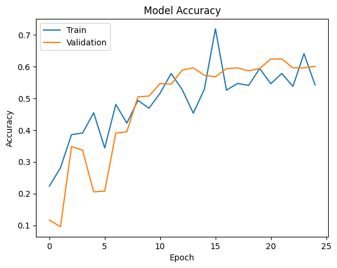

```python
plt.plot(history.history['accuracy'])
plt.plot(history.history['val_accuracy'])
plt.title('Model Accuracy')
plt.ylabel('Accuracy')
plt.xlabel('Epoch')
plt.legend(['Train', 'Validation'], loc='upper left')
plt.show()
```

```python
modeldesc="CNN with Data Augmentation"
training_df = model_performance(model_da, X_train_normalized, y_train_encoded,modeldesc)
validation_df = model_performance(model_da, X_val_normalized, y_val_encoded,modeldesc)


training_results = pd.concat([training_results,training_df], ignore_index=True)
validation_results = pd.concat([validation_results, validation_df], ignore_index=True)
```

```
121/121 ━━━━━━━━━━━━━━━━━━━━ 1s 5ms/step
14/14 ━━━━━━━━━━━━━━━━━━━━ 0s 21ms/step
```

```python
training_results[training_results['Model']==modeldesc]
```

|  | Model | Accuracy | Recall | Precision | F1 |
| --- | --- | --- | --- | --- | --- |
| 1 | CNN with Data Augmentation | 0.63556 | 0.63556 | 0.599032 | 0.583146 |

```python
validation_results[validation_results['Model']==modeldesc]
```

|  | Model | Accuracy | Recall | Precision | F1 |
| --- | --- | --- | --- | --- | --- |
| 1 | CNN with Data Augmentation | 0.600467 | 0.600467 | 0.54559 | 0.539558 |

#### **Evaluating the model on test data**

```python
accuracy = model_da.evaluate(X_test_normalized, y_test_encoded, verbose=2)
```

```
15/15 - 0s - 32ms/step - accuracy: 0.5874 - loss: 1.2422
```

```python
test_df = model_performance(model_da, X_test_normalized, y_test_encoded,modeldesc)
test_results = pd.concat([test_results,test_df], ignore_index=True)
```

```
15/15 ━━━━━━━━━━━━━━━━━━━━ 0s 21ms/step
```

```python
test_results[test_results['Model']==modeldesc]
```

|  | Model | Accuracy | Recall | Precision | F1 |
| --- | --- | --- | --- | --- | --- |
| 1 | CNN with Data Augmentation | 0.587368 | 0.587368 | 0.539939 | 0.536364 |

#### **Generating the predictions using test data**

```python
# Here we would get the output as probablities for each category
y_pred=model_da.predict(X_test_normalized)
```

```
15/15 ━━━━━━━━━━━━━━━━━━━━ 0s 4ms/step
```

```python
y_pred
```

```
array([[1.1818336e-04, 1.0471025e-03, 2.4754796e-05, ..., 3.8630642e-02,
        8.9952000e-06, 7.8934175e-04],
       [1.6881361e-03, 1.6784197e-01, 5.5768032e-02, ..., 1.2317168e-01,
        5.4642773e-01, 2.6451454e-03],
       [3.0649710e-03, 2.9683307e-02, 1.3863252e-02, ..., 2.8101243e-02,
        8.0064774e-01, 4.7891820e-03],
       ...,
       [1.7130838e-01, 1.3080484e-02, 3.2975975e-02, ..., 2.7755160e-02,
        1.5650366e-02, 1.4805120e-02],
       [2.4048588e-03, 5.3763807e-02, 2.3334039e-02, ..., 8.8436879e-02,
        5.2372110e-03, 4.4886000e-03],
       [1.4206820e-02, 1.8538547e-01, 1.7960187e-02, ..., 2.3901527e-01,
        1.3550653e-01, 4.9148905e-03]], dtype=float32)
```

#### **Plotting the Confusion Matrix**

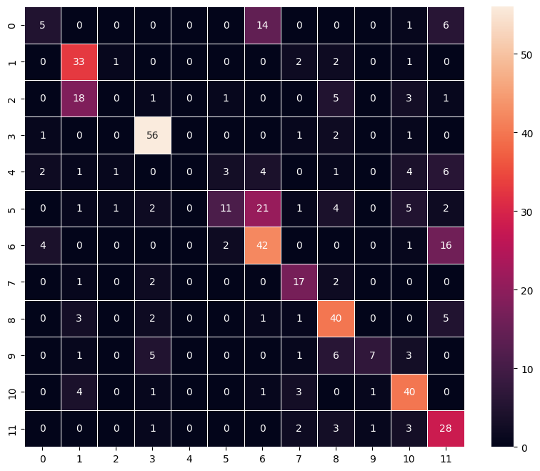

```python
# Obtaining the categorical values from y_test_encoded and y_pred
y_pred_arg=np.argmax(y_pred,axis=1)
y_test_arg=np.argmax(y_test_encoded,axis=1)

# Plotting the Confusion Matrix using confusion matrix() function which is also predefined tensorflow module
confusion_matrix = tf.math.confusion_matrix(y_test_arg,y_pred_arg)
f, ax = plt.subplots(figsize=(10, 8))
sns.heatmap(
    confusion_matrix,
    annot=True,
    linewidths=.4,
    fmt="d",
    square=True,
    ax=ax
)
plt.show()
```

## Final Model

The metrics for base CNN model and CNN model with data augmentation are summarized below for training, validation and test data.

```python
#Make 'Model' as index
training_results.set_index('Model',inplace=True)
validation_results.set_index('Model',inplace=True)
test_results.set_index('Model',inplace=True)
```

**Training Data Performance**

```python
training_results
```

| Model | Accuracy | Recall | Precision | F1 |
| --- | --- | --- | --- | --- |
| CNN | 0.655056 | 0.655056 | 0.602149 | 0.577568 |
| CNN with Data Augmentation | 0.635560 | 0.635560 | 0.599032 | 0.583146 |

**Validation Data Performance**

```python
validation_results
```

| Model | Accuracy | Recall | Precision | F1 |
| --- | --- | --- | --- | --- |
| CNN | 0.574766 | 0.574766 | 0.492668 | 0.497251 |
| CNN with Data Augmentation | 0.600467 | 0.600467 | 0.545590 | 0.539558 |

**Test Data Performance**

```python
test_results
```

| Model | Accuracy | Recall | Precision | F1 |
| --- | --- | --- | --- | --- |
| CNN | 0.560000 | 0.560000 | 0.463832 | 0.482869 |
| CNN with Data Augmentation | 0.587368 | 0.587368 | 0.539939 | 0.536364 |

**Accuracy - Training, Validation and Test data**

```python
# Summarize accuracy for training, validation and test data for the two models
pd.DataFrame({'Train Accuracy':training_results['Accuracy'],'Validation Accuracy':validation_results['Accuracy'],'Test Accuracy':test_results['Accuracy']})
```

| Model | Train Accuracy | Validation Accuracy | Test Accuracy |
| --- | --- | --- | --- |
| CNN | 0.655056 | 0.574766 | 0.560000 |
| CNN with Data Augmentation | 0.635560 | 0.600467 | 0.587368 |

**Conclusion**

Based on the comparative analysis of the base CNN model and the CNN model with data augmentation, the CNN with Data Augmentation is the best model for Plant Seedlings Classification. This conclusion is supported by the following observations:

- **Improved Overall Accuracy:** The CNN with Data Augmentation achieved a higher test accuracy of 58.74%, compared to the base CNN model's 56%. This indicates an improvement in the model's ability to generalize to unseen data.
- **Reduced Overfitting:** The data augmentation model demonstrates a smaller gap between training and validation accuracy, suggesting reduced overfitting and better generalization.
- **Enhanced Precision and Recall:** The CNN with data augmentation model exhibits improved precision and recall scores for validation and test data, indicating a better balance in correctly classifying both positive and negative instances.

Though the base CNN model has a slightly higher training accuracy (0.655056 vs. 0.635560), this advantage is outweighed by its poorer generalization, making the CNN with Data Augmentation the clear winner.

### Visualizing the prediction

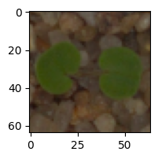

```
1/1 ━━━━━━━━━━━━━━━━━━━━ 0s 401ms/step
Predicted Label ['Small-flowered Cranesbill']
True Label Small-flowered Cranesbill
```

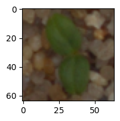

```
1/1 ━━━━━━━━━━━━━━━━━━━━ 0s 33ms/step
Predicted Label ['Charlock']
True Label Cleavers
```

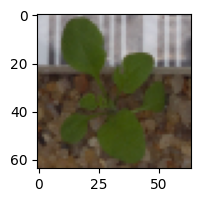

```
1/1 ━━━━━━━━━━━━━━━━━━━━ 0s 37ms/step
Predicted Label ['Shepherds Purse']
True Label Shepherds Purse
```

```python
# Visualizing the predicted and correct label of images from test data, for the final model (CNN with data augmentation)
plt.figure(figsize=(2,2))
plt.imshow(X_test[2])
plt.show()
print('Predicted Label', enc.inverse_transform(model_da.predict((X_test_normalized[2].reshape(1,64,64,3)))))   # reshaping the input image as we are only trying to predict using a single image
print('True Label', enc.inverse_transform(y_test_encoded)[2])                                               # using inverse_transform() to get the output label from the output vector

plt.figure(figsize=(2,2))
plt.imshow(X_test[33])
plt.show()
print('Predicted Label', enc.inverse_transform(model_da.predict((X_test_normalized[33].reshape(1,64,64,3)))))  # reshaping the input image as we are only trying to predict using a single image
print('True Label', enc.inverse_transform(y_test_encoded)[33])                                              # using inverse_transform() to get the output label from the output vector

plt.figure(figsize=(2,2))
plt.imshow(X_test[36])
plt.show()
print('Predicted Label', enc.inverse_transform(model_da.predict((X_test_normalized[36].reshape(1,64,64,3)))))  # reshaping the input image as we are only trying to predict using a single image
print('True Label', enc.inverse_transform(y_test_encoded)[36])                                              # using inverse_transform() to get the output label from the output vector
```

## Actionable Insights and Business Recommendations

**Actionable Insights**

- **Dataset Imbalance Affects Performance:** Imbalanced data (e.g., ~200 samples for Common Wheat, Maize vs. 600+ for Loose Silky-bent) leads to complete misclassification of underrepresented classes.
- **Data Augmentation Improves Generalization:** CNN with Data Augmentation achieves better test accuracy (58.74% vs. 56.00%) and reduces overfitting (training-to-validation gap: 0.035093 vs. 0.080290).
- **Suboptimal Model Performance:** Test accuracy of 58.74% (Final CNN Model with data augmentation) is too low for practical use; the final model may not capture complex plant features.
- **Feature Overlap Problem:** Species with similar leaf shape, color, or growth patterns are frequently misclassified.

**Business Recommendations**

- **Balance the Dataset:** Collect more images for underrepresented classes (e.g., Common Wheat, Maize).
- **Enhance Data Augmentation:** Apply advanced augmentation (e.g., rotation, color jittering) and feature engineering (e.g., edge detection for leaf shape) to better distinguish similar species.
- **Use Advanced Models:** Experiment with advanced models and leverage transfer learning to improve accuracy for complex plant image classification.
- **Prioritize High-Impact Classes:** Focus on accurate classification of weeds (e.g., Black-grass, Cleavers) and crops (e.g., Common Wheat).
- **Implement Two-Stage Classification:** Group similar classes (e.g., grass-like weeds) and use a secondary classifier to distinguish them, addressing feature overlap issues.
- **Deploy in a User-Friendly App:** Integrate the classifier into a mobile/web app with real-time identification, confidence scores, and weed/crop management recommendations for farmers.
- **Enable Continuous Improvement:** Create a feedback loop for farmers to report misclassifications, retrain the model with new data, and monitor performance in real-world conditions.